# Camera-Trap Monitoring Report: GMU8 Leuven, Belgium

Ecological insights from camera-trap data for wildlife monitoring

Martijn Bollen, Niko Boone, Jim Casaer, Peter Desmet, Sander Devisscher, Sanne Govaert, Lynn Pallemaerts, Anneleen Rutten, and Jan Vercammen

Research Institute for Nature and Forest (INBO)

June 18, 2026

[figure not shown]

# 1 Introduction

Terrestrial wildlife populations play a fundamental role in ecosystem structure and function. Across taxonomic groups, wildlife contributes to key ecological processes such as nutrient cycling, energy flow, seed dispersal, trophic interactions, and habitat modification, thereby supporting biodiversity and strengthening ecosystem resilience (*Dirzo et al., 2014*). However, these populations are increasingly exposed to anthropogenic pressures, especially habitat alteration and land-use change, which may affect their distribution and abundance across space and time (*Newbold et al., 2015*). Understanding and monitoring these responses is therefore crucial for conservation planning, effective protected-area management, and evidence-based decision-making (*Coad et al., 2015*).

To better understand and monitor these responses, camera trapping has become a cost-effective, reliable, and non-invasive method for monitoring wildlife populations. By automatically capturing images or videos when animals move through the detection zone of infrared sensors, camera traps generate robust information on species occurrence, habitat use, activity patterns, and relative abundance while minimizing observer-related disturbance. Consequently, camera-trap data have become an important source of biodiversity information and are widely applied in ecological research, biodiversity monitoring, and adaptive conservation management (*Kays et al., 2009*). These data are valuable to both scientists and practitioners, as they support ecological analyses, advance understanding of species ecology, and provide critical insights into population status and trends (*O’Connell et al., 2011*).

This report presents the results of camera-trap surveys conducted in **GMU8 LEUVEN**, **Belgium**. The aim is to estimate and monitor **Artiodactyla and Carnivora** over time and across deployments, and to provide insight into wildlife status at this site, including behaviour and changes in spatial and temporal patterns.

# 2 Methods

## 2.1 Study Area

The study was conducted in natural habitats south of Leuven, Belgium, as part of the GMU8_LEUVEN camera-trap monitoring dataset published by the Research Institute for Nature and Forest (INBO). Monitoring started in March 2018 and covered several forest and nature areas, including the main forest complexes of Meerdaalwoud, Heverleebos, and Egenhovenbos, as well as parts of the Dijle, Laan, and Yse river valleys.

The monitoring was primarily designed to study the interaction between human activities, such as recreation and hunting, and the population dynamics, spatial distribution, and temporal activity of roe deer (*Capreolus capreolus*) and wild boar (*Sus scrofa*). However, the dataset also includes all mammal and bird observations recorded during the survey period.

Camera locations were selected using a 250 × 250 m grid-based sampling design. A total of 32 camera traps were deployed, facing north at approximately 50 cm above ground, without bait. Cameras were relocated monthly, and each selected grid cell was monitored once in winter and once in summer. Images were annotated in Agouti and standardised to Darwin Core using the `camtrapdp` R package.

## 2.2 Sampling

The sampling design at this site is systematic random. In a systematic random design, camera locations are initially chosen at random but then arranged in a regular pattern, such as a grid, providing more even spatial coverage while retaining a random starting point. Multiple camera heights were used at this site, ranging from 0.15 to 5 m above the ground. Media were captured using time-lapse and activity detection. This project was not specifically designed to identify individual animals, but rather to support broader wildlife monitoring. More detailed information on camera-trap deployments by survey year is provided in the summarized information table below.

**📷 Camera Deployment Summary**

**Table 1**: Details of camera deployments per year

| Year | Camera Traps | Deployment Period | Setup Period | Pickup Period |
| --- | --- | --- | --- | --- |
| 2018 | 245 | 2018-03-25 - 2019-01-29 | 25 March - 20 December | January 25 - January 29 |
| 2019 | 348 | 2019-01-19 - 2020-03-31 | 19 January - 30 December | March 31 - March 31 |
| 2020 | 373 | 2020-01-02 - 2021-02-21 | 02 January - 06 December | February 21 - February 21 |
| 2021 | 395 | 2021-01-02 - 2022-02-02 | 02 January - 31 December | January 29 - February 02 |
| 2022 | 386 | 2022-01-03 - 2023-02-01 | 03 January - 28 December | January 27 - February 01 |
| 2023 | 363 | 2023-01-02 - 2024-02-02 | 02 January - 29 December | February 02 - February 02 |
| 2024 | 371 | 2024-01-03 - 2025-01-29 | 03 January - 30 December | January 29 - January 29 |
| 2025 | 216 | 2025-01-02 - 2025-09-02 | 02 January - 01 August | September 01 - September 02 |

## 2.3 Camera Locations

The maps below display the locations of camera traps deployed during different years. Use the tabs above to explore data for each sampling year. The last tab shows the study area with all camera locations in this site. Locations are color-coded by habitat type. Click on the points for additional deployment information.

### 2018

[interactive chart not shown]

### 2019

[interactive chart not shown]

### 2020

[interactive chart not shown]

### 2021

[interactive chart not shown]

### 2022

[interactive chart not shown]

### 2023

[interactive chart not shown]

### 2024

[interactive chart not shown]

### 2025

[interactive chart not shown]

### Total

[interactive chart not shown]

**Figure.1**: *Interactive map of camera trap locations. Click on a marker to view the corresponding location details and additional metadata.*

## 2.4 Sampling Efforts

Sampling effort refers to the total number of camera trap operational days, accounting for both the number of active cameras and their duration of deployment. It provides critical context for interpreting species detection rates and comparing data across years. A summary of yearly sampling effort is provided below, including camera breakdowns, average operational days, and total effort per year:

- **2018:** 231 cameras broke down during the study period, the cameras operated for an average of 36 days (range: 24 - 53 days), and the total sampling effort was 8725 days, equivalent to 23.9 years.
- **2019:** 347 cameras broke down during the study period, the cameras operated for an average of 32 days (range: 2 - 327 days), and the total sampling effort was 11063 days, equivalent to 30.31 years.
- **2020:** 372 cameras broke down during the study period, the cameras operated for an average of 31 days (range: 3 - 326 days), and the total sampling effort was 11403 days, equivalent to 31.24 years.
- **2021:** 383 cameras broke down during the study period, the cameras operated for an average of 30 days (range: 5 - 43 days), and the total sampling effort was 11665 days, equivalent to 31.96 years.
- **2022:** 367 cameras broke down during the study period, the cameras operated for an average of 30 days (range: 1 - 38 days), and the total sampling effort was 11393 days, equivalent to 31.21 years.
- **2023:** 360 cameras broke down during the study period, the cameras operated for an average of 30 days (range: 12 - 38 days), and the total sampling effort was 10983 days, equivalent to 30.09 years.
- **2024:** 369 cameras broke down during the study period, the cameras operated for an average of 30 days (range: 19 - 37 days), and the total sampling effort was 11232 days, equivalent to 30.77 years.
- **2025:** 212 cameras broke down during the study period, the cameras operated for an average of 30 days (range: 4 - 35 days), and the total sampling effort was 6400 days, equivalent to 17.53 years.

The following figure provides detailed information on sampling effort over time, and the slider can be used to focus on specific time periods.

[interactive chart not shown]

**Figure.2**: *Number of active camera traps per survey year. Adjust the slider to focus on specific time periods.*

## 2.5 Image Processing

To support standardized, reproducible, and interoperable workflows, camera-trap data are increasingly managed using dedicated platforms such as [Agouti](https://agouti.eu/) (*Casaer et al., 2019*) and structured according to community standards such as [CamtrapDP](https://camtrap-dp.tdwg.org/) (*Bubnicki et al., 2024*). Agouti supports sequence-based annotation, AI-assisted classification, secure archiving, and standardized data export. In this workflow, images recorded within 120 seconds of one another were grouped into sequences representing putative single events and annotated using a combination of AI-assisted classification and manual review; a subset was subsequently validated by experienced observers. Where relevant for density estimation, calibration images and species-specific movement paths were also annotated and analysed using the photogrammetric tools in the R package camtrapDensity (*Rowcliffe, 2014*).

The images used in this report were processed and archived in Agouti , and the data were structured according to the CamtrapDP standard.

## 2.6 Data Processing

The input data were provided in [Camtrap-DP standard format](https://camtrap-dp.tdwg.org/) and pre-processed in camtrapReport, including cleaning, harmonisation, organisation, summarisation, and extraction of key attributes. Records were checked for completeness and internal consistency before being summarised into the descriptive statistics and ecological metrics presented in this report.

In the processing stage, ecological analysis modules operated on these standardised data to generate harmonised outputs, including tables, figures, text, and summary statistics. The report includes a broad range of ecological analyses, such as sampling effort, species richness, activity patterns, and species co-occurrence. These analyses draw on established ecological methods implemented in dedicated R packages, including activity and camtrapDensity.

In the post-processing stage, outputs generated by the selected modules were assembled into structured report sections and rendered into a coherent, article-style ecological report. Because sections can be customised by the user, the report structure remains flexible and can be adapted to different study objectives. This workflow provides a reproducible and extensible framework for transforming raw camera-trap data into standardised ecological insights.

# 3 Results

## 3.1 Captures

This section presents an overview of the camera-trap capture data collected during the study period. Across 2018, 2019, 2020, 2021, 2022, 2023, 2024, and 2025, the survey recorded 36 wild species and 6 domestic species. Human presence was also detected on 2154 occasions, most likely associated with field visits for camera installation or maintenance.

The report focuses on **Artiodactyla and Carnivora** recorded in at least **25** capture events during the study period. The following table summarizes these frequently detected species and provides the main capture-based metrics for each species, including capture events, Relative Abundance Index (RAI; captures per 100 trap-days), number of capture locations, and total photos.

**🐾 Table 2. Summary of Frequently Detected Artiodactyla_and_Carnivora**

Species with ≥ 25 capture events

| Common Name | Scientific Name | Captures | RAI | Capture Locations | Total Photos |
| --- | --- | --- | --- | --- | --- |
| roe deer | Capreolus capreolus | 28218 | 34.03 | 2133 | 834212 |
| wild boar | Sus scrofa | 11304 | 13.63 | 1620 | 483574 |
| red fox | Vulpes vulpes | 7624 | 9.19 | 1428 | 102236 |
| beech marten | Martes foina | 734 | 0.88 | 347 | 9679 |
| domestic cat | Felis catus | 611 | 0.74 | 180 | 8888 |
| fallow deer | Dama dama | 312 | 0.38 | 74 | 11451 |
| cattle | Bos taurus | 223 | 0.27 | 22 | 15632 |
| domestic sheep | Ovis aries | 76 | 0.09 | 11 | 4980 |
| European polecat | Mustela putorius | 66 | 0.08 | 47 | 710 |
| raccoon | Procyon lotor | 48 | 0.06 | 26 | 680 |

## 3.2 Capture-Based and Abundance Trends

Camera-trap capture data do not directly measure true population size, but they can provide useful indicators of temporal variation in relative abundance and species detectability, provided that survey effort and detection conditions remain reasonably comparable among years.

The figures below summarize capture-based trends for frequently detected Artiodactyla and Carnivora recorded in at least 25 capture events during the study period in GMU8 LEUVEN. The tabs present complementary metrics, including the number of captures, capture rate (captures per 100 trap-days), number of capture locations, and, where available, REM-based density estimates. Together, these metrics support comparison of temporal patterns in species records across survey years.

### Number of Captures

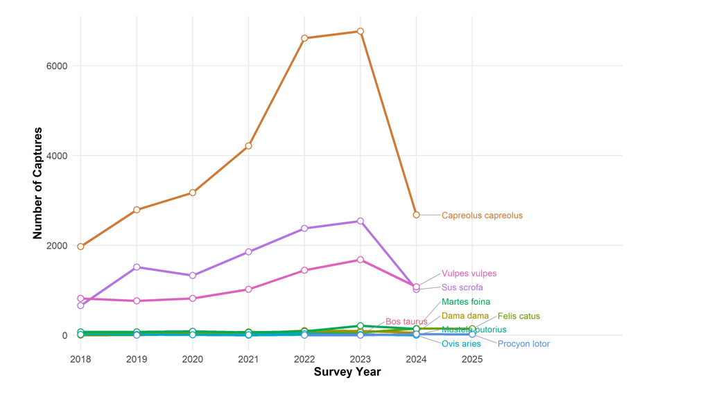

**Figure 3.** *Trends in camera-trap detections over the survey years for each study species in the Artiodactyla and Carnivora group, based on the number of captures.*

### Capture Rate

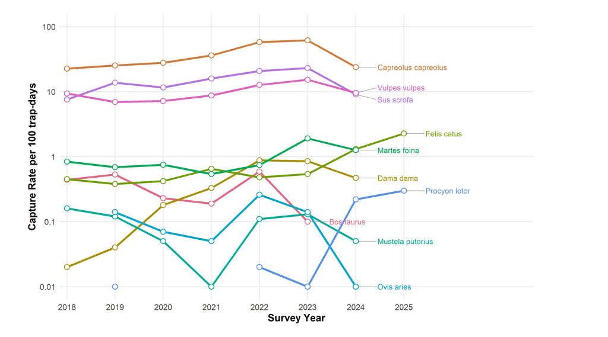

**Figure 4.** *Capture rates per 100 trap-days are shown on a log10 scale for each study species in the Artiodactyla and Carnivora group across survey years.*

### Number of Locations

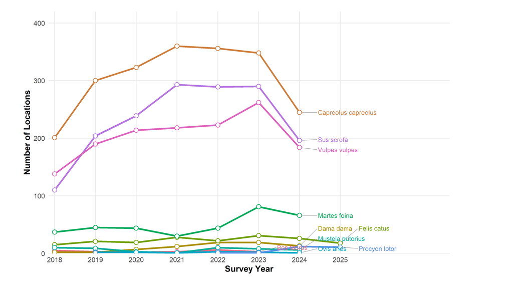

**Figure 5.** *Trends in the number of camera-trap locations where each species was recorded in the Artiodactyla and Carnivora group across survey years.*

### REM-Based Density

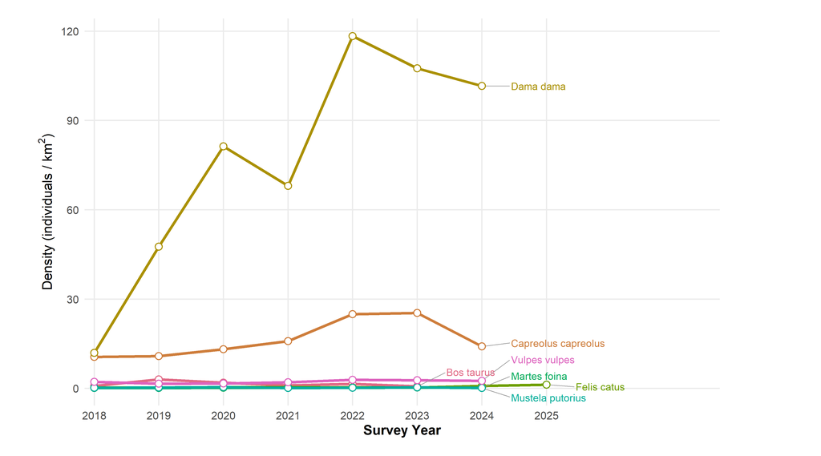

**Figure 6.** *Trends in estimated REM-based population density for each study species in the Artiodactyla and Carnivora group across survey years.*

## 3.3 Population Density Estimation

Population density was estimated using the Random Encounter Model (REM) for species with sufficient data to support reliable parameter estimation (*Palencia et al., 2022*). All REM analyses were conducted using the camtrapDensity R package. Because detectability may vary among species, habitat types, and camera models, these estimates should be interpreted with reference to the assumptions of the model. The estimated model parameters and derived density values are presented in the following sections. For consistency, all density estimates were calculated using parameter values averaged across sampling rounds.

### 3.3.1 REM Model Parameters

The REM relies on three key parameters: movement speed, activity level, and day range. Movement speed represents the average distance travelled by an individual over time, whereas activity level reflects the proportion of time individuals are active and therefore available for detection by camera traps. Day range refers to the total distance an animal typically moves within a 24-hour period and is derived from movement speed and activity level (Rowcliffe et al., 2008; Rowcliffe et al., 2016). Together, these parameters underpin the REM density estimates presented in this section. The tabs below show species-specific estimates for each parameter.

#### Movement Speed

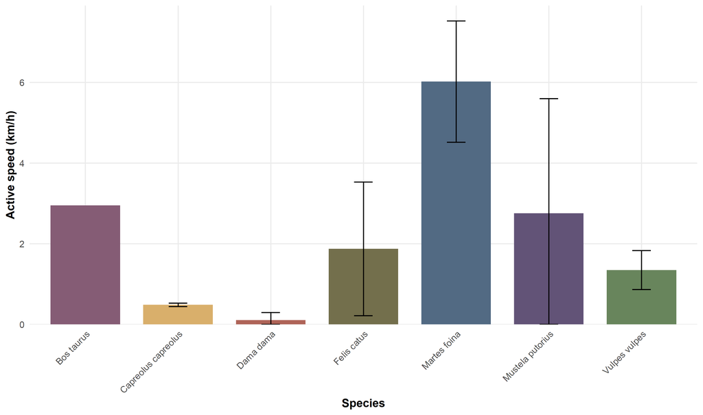

**Figure 7.** *Estimated active movement speeds (km/h) across study species. Error bars show 95% confidence intervals.*

#### Activity Level

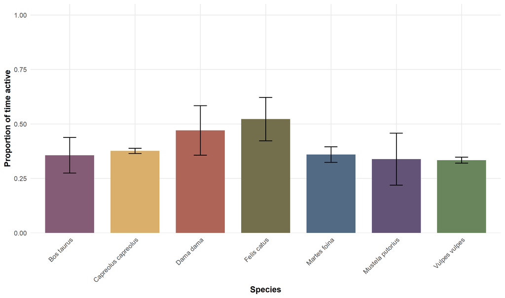

**Figure 8.** *Estimated activity levels, expressed as the proportion of the day active, for each study species. Error bars show 95% confidence intervals.*

#### Day Range

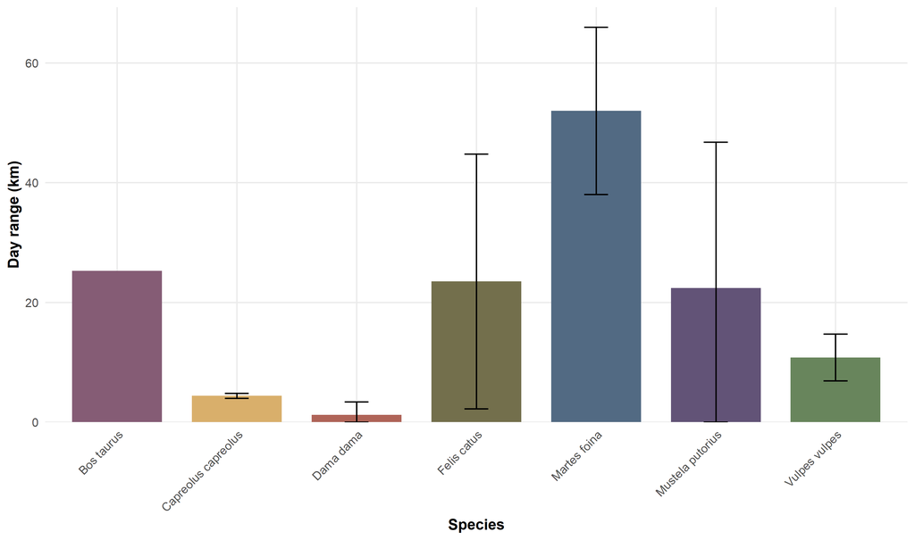

**Figure 9.** *Estimated day ranges for each study species, calculated as the product of movement speed and activity level scaled to a 24-hour period. Error bars show 95% confidence intervals.*

### 3.3.2 Population Density Estimates

The plots below show annual population density estimates for each study species, together with 95% confidence intervals. These estimates allow comparison of temporal variation in density across survey years.

#### Bos taurus

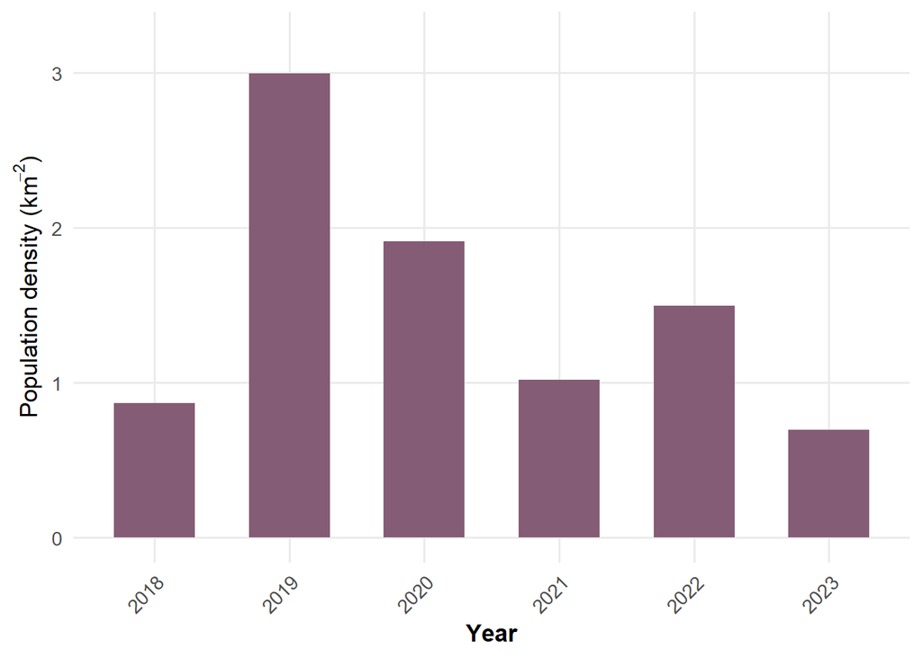

#### Capreolus capreolus

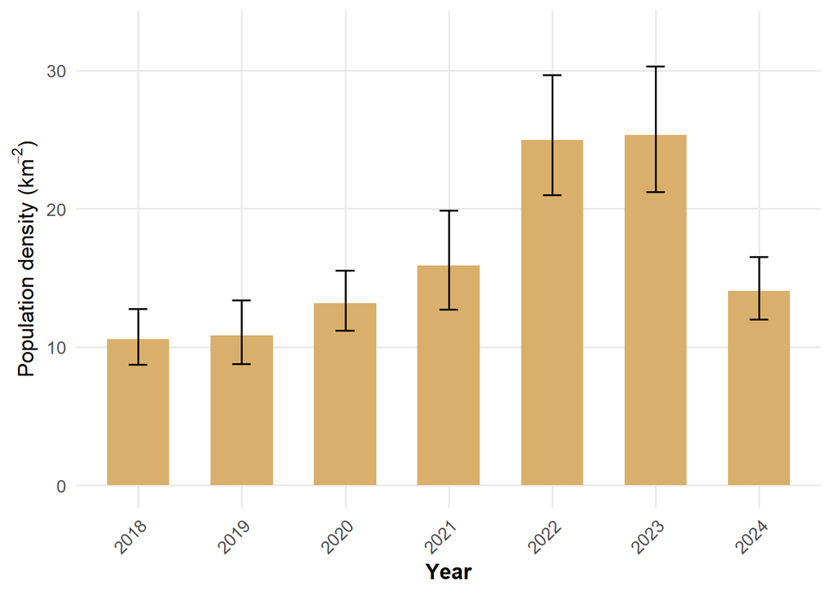

**Figure.11**: *Estimated population density per sampling year for Capreolus capreolus. Whiskers represent the 95% confidence intervals.*

#### Dama dama

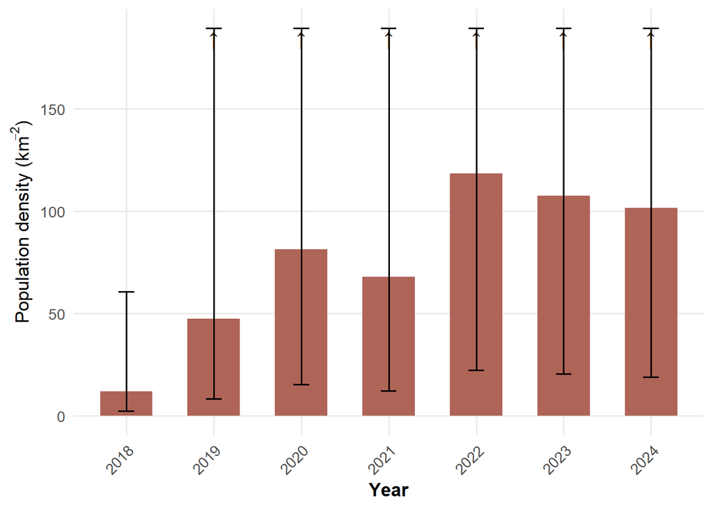

*Note: The confidence intervals for **Dama dama** are extremely wide relative to the point estimates. The y-axis has been restricted for readability. Upward arrows indicate confidence intervals that extend beyond the displayed range. This indicates high uncertainty in the REM estimate and should be interpreted cautiously.*

**Figure.12**: *Estimated population density per sampling year for Dama dama. Whiskers represent the 95% confidence intervals; upward arrows indicate confidence intervals extending beyond the displayed y-axis range.*

#### Felis catus

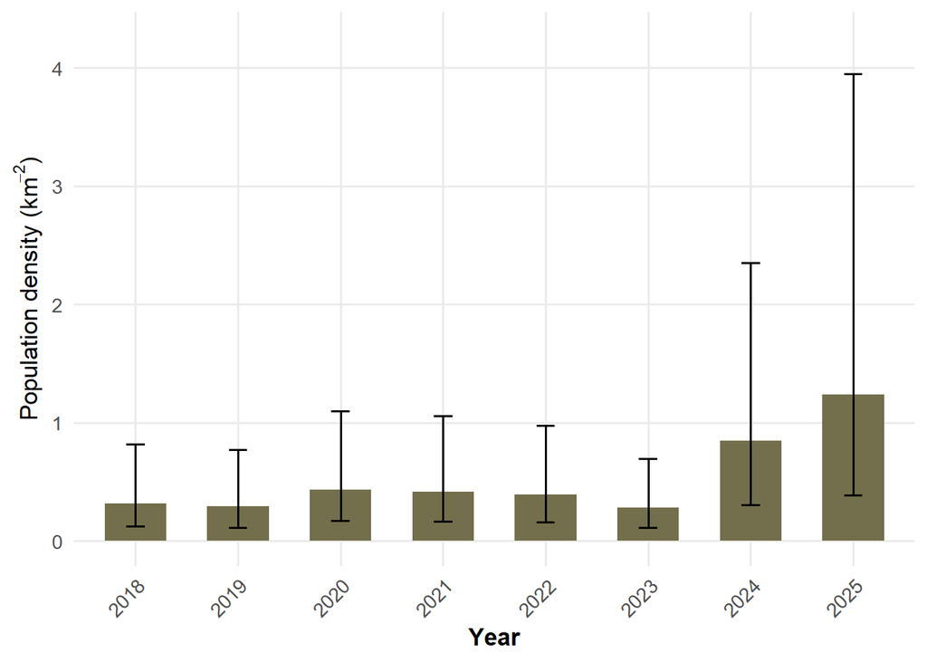

**Figure.13**: *Estimated population density per sampling year for Felis catus. Whiskers represent the 95% confidence intervals.*

#### Martes foina

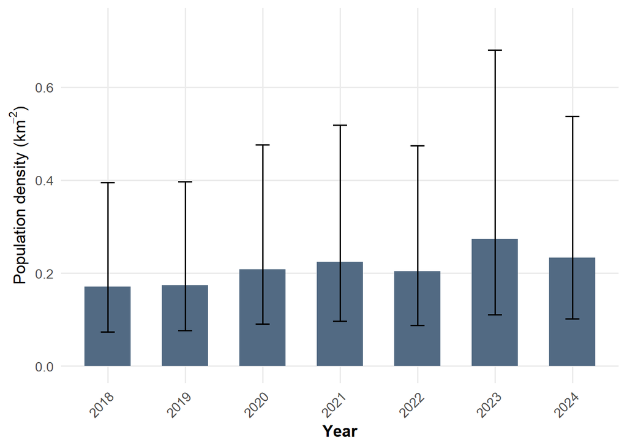

**Figure.14**: *Estimated population density per sampling year for Martes foina. Whiskers represent the 95% confidence intervals.*

#### Mustela putorius

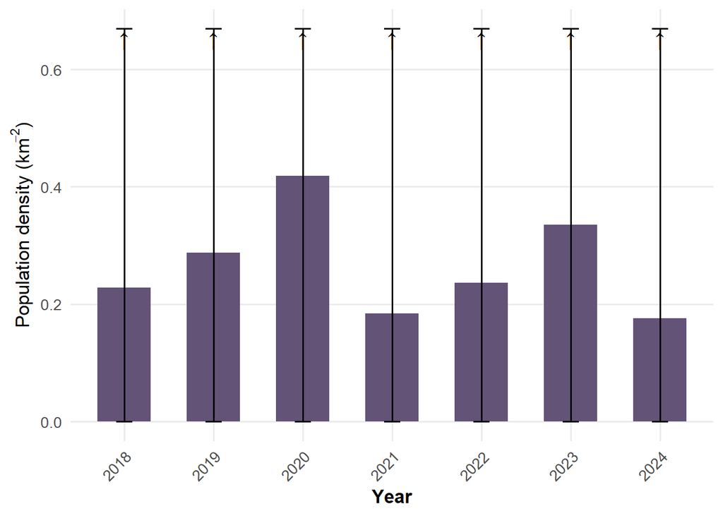

*Note: The confidence intervals for **Mustela putorius** are extremely wide relative to the point estimates. The y-axis has been restricted for readability. Upward arrows indicate confidence intervals that extend beyond the displayed range. This indicates high uncertainty in the REM estimate and should be interpreted cautiously.*

**Figure.15**: *Estimated population density per sampling year for Mustela putorius. Whiskers represent the 95% confidence intervals; upward arrows indicate confidence intervals extending beyond the displayed y-axis range.*

#### Vulpes vulpes

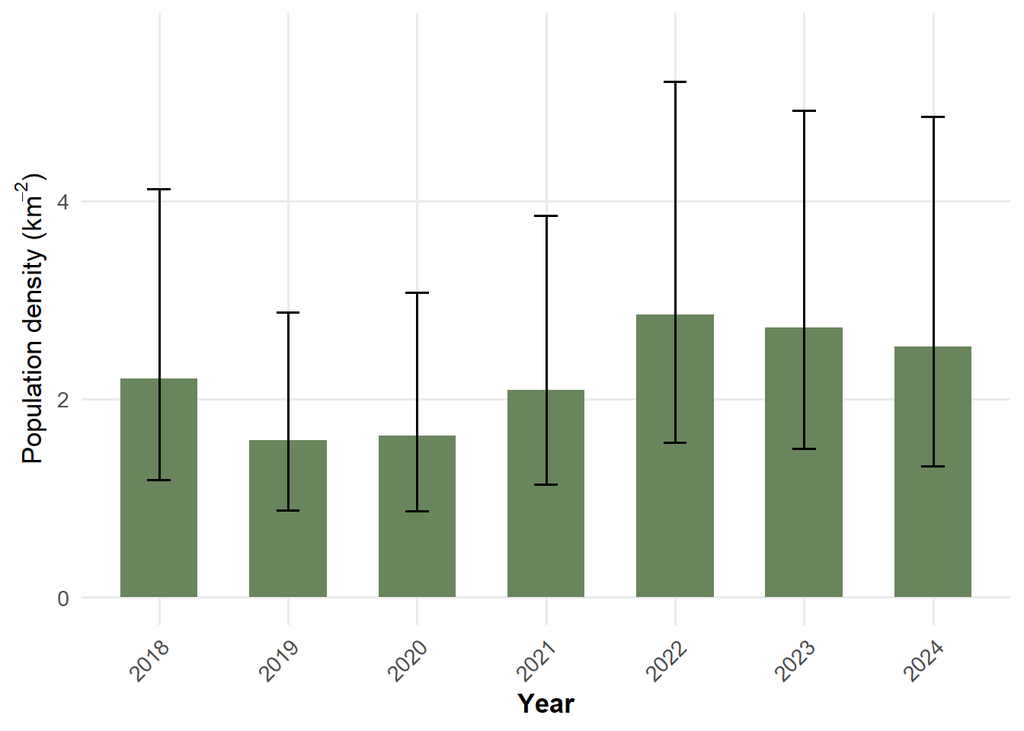

**Figure.16**: *Estimated population density per sampling year for Vulpes vulpes. Whiskers represent the 95% confidence intervals.*

## 3.4 Activity Patterns

Activity patterns describe the temporal distribution of animal activity across the 24-hour day and are typically inferred from the timing of camera-trap detections. These patterns help identify whether species are primarily diurnal, nocturnal, or crepuscular, and can provide insight into daily behavior, ecological roles, and potential responses to environmental factors or human disturbance. The figures below present estimated daily activity curves for each study species, based on camera-trap detections collected across the monitoring period and derived using functionality from the activity R package (*Rowcliffe, 2016*).

### Bos taurus

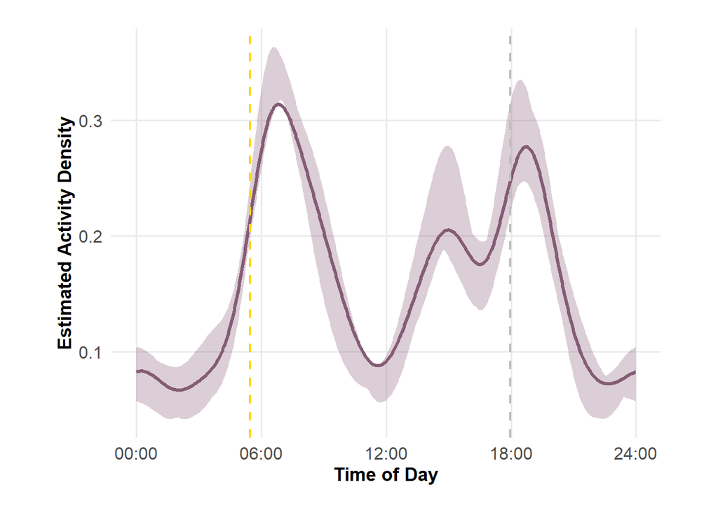

**Figure.17**: *Estimated daily activity pattern for Bos taurus, aggregated across all sampling rounds. Dashed lines indicate the average sunrise (yellow) and sunset (gray) times across survey years. The solid line shows the fitted activity model, and the shaded region shows the 95% CI.*

### Capreolus capreolus

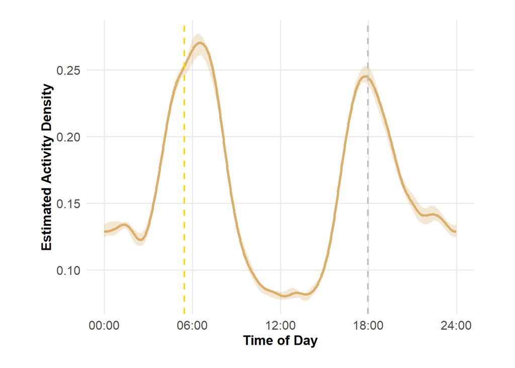

**Figure.18**: *Estimated daily activity pattern for Capreolus capreolus, aggregated across all sampling rounds. Dashed lines indicate the average sunrise (yellow) and sunset (gray) times across survey years. The solid line shows the fitted activity model, and the shaded region shows the 95% CI.*

### Dama dama

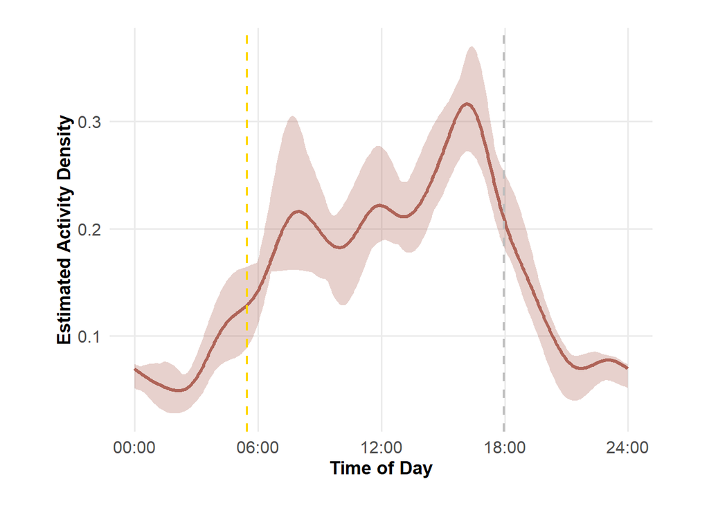

**Figure.19**: *Estimated daily activity pattern for Dama dama, aggregated across all sampling rounds. Dashed lines indicate the average sunrise (yellow) and sunset (gray) times across survey years. The solid line shows the fitted activity model, and the shaded region shows the 95% CI.*

### Felis catus

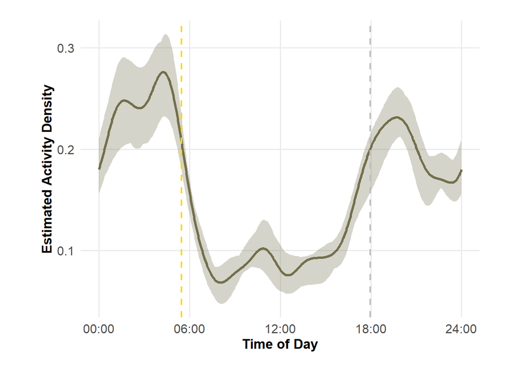

**Figure.20**: *Estimated daily activity pattern for Felis catus, aggregated across all sampling rounds. Dashed lines indicate the average sunrise (yellow) and sunset (gray) times across survey years. The solid line shows the fitted activity model, and the shaded region shows the 95% CI.*

### Martes foina

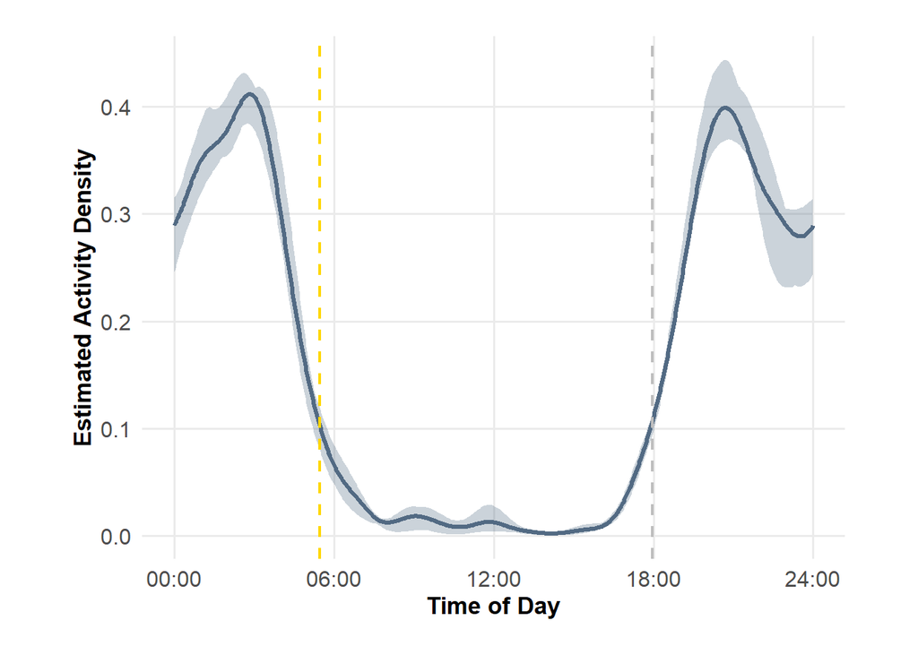

**Figure.21**: *Estimated daily activity pattern for Martes foina, aggregated across all sampling rounds. Dashed lines indicate the average sunrise (yellow) and sunset (gray) times across survey years. The solid line shows the fitted activity model, and the shaded region shows the 95% CI.*

### Mustela putorius

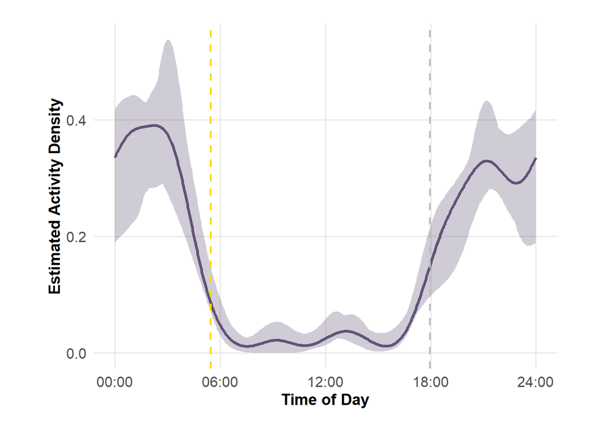

**Figure.22**: *Estimated daily activity pattern for Mustela putorius, aggregated across all sampling rounds. Dashed lines indicate the average sunrise (yellow) and sunset (gray) times across survey years. The solid line shows the fitted activity model, and the shaded region shows the 95% CI.*

### Ovis aries

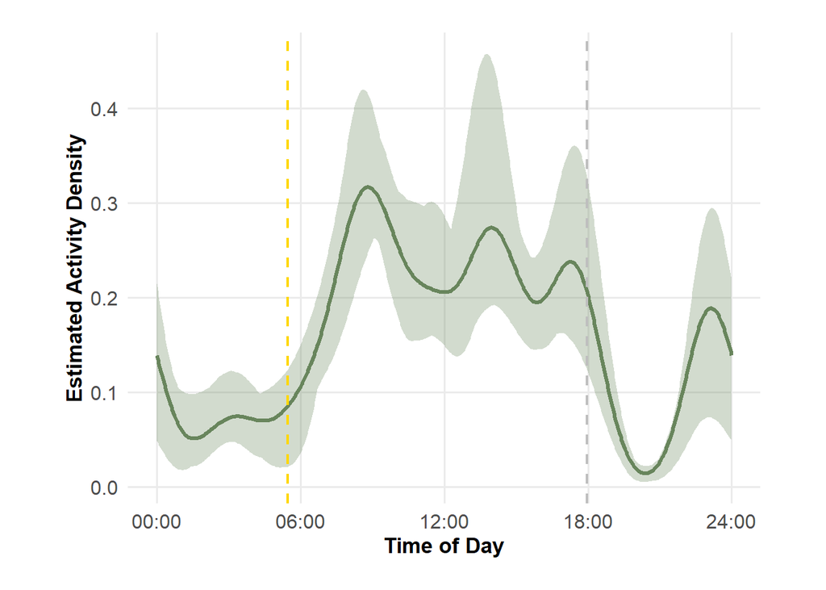

**Figure.23**: *Estimated daily activity pattern for Ovis aries, aggregated across all sampling rounds. Dashed lines indicate the average sunrise (yellow) and sunset (gray) times across survey years. The solid line shows the fitted activity model, and the shaded region shows the 95% CI.*

### Procyon lotor

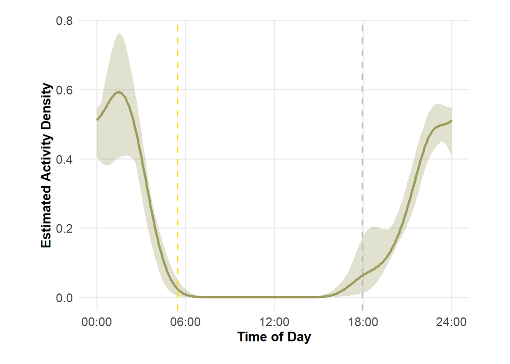

**Figure.24**: *Estimated daily activity pattern for Procyon lotor, aggregated across all sampling rounds. Dashed lines indicate the average sunrise (yellow) and sunset (gray) times across survey years. The solid line shows the fitted activity model, and the shaded region shows the 95% CI.*

### Sus scrofa

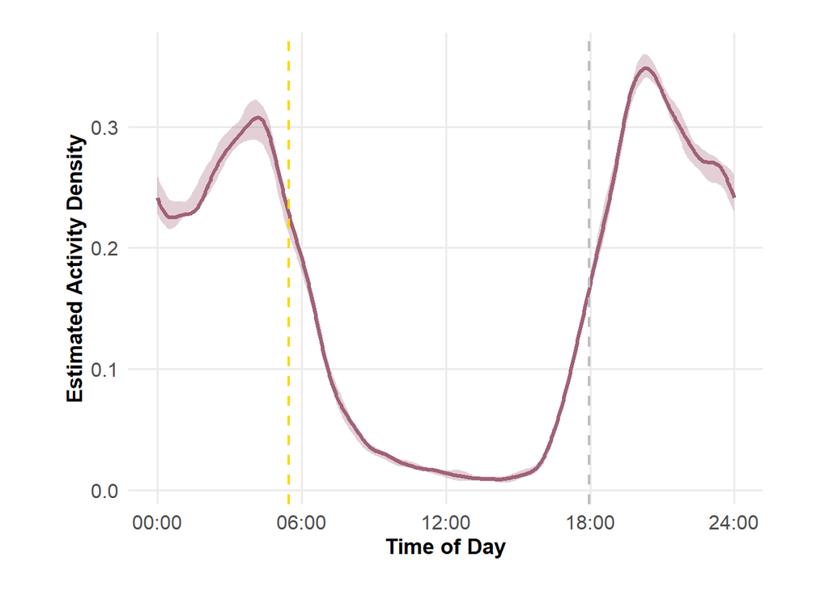

**Figure.25**: *Estimated daily activity pattern for Sus scrofa, aggregated across all sampling rounds. Dashed lines indicate the average sunrise (yellow) and sunset (gray) times across survey years. The solid line shows the fitted activity model, and the shaded region shows the 95% CI.*

### Vulpes vulpes

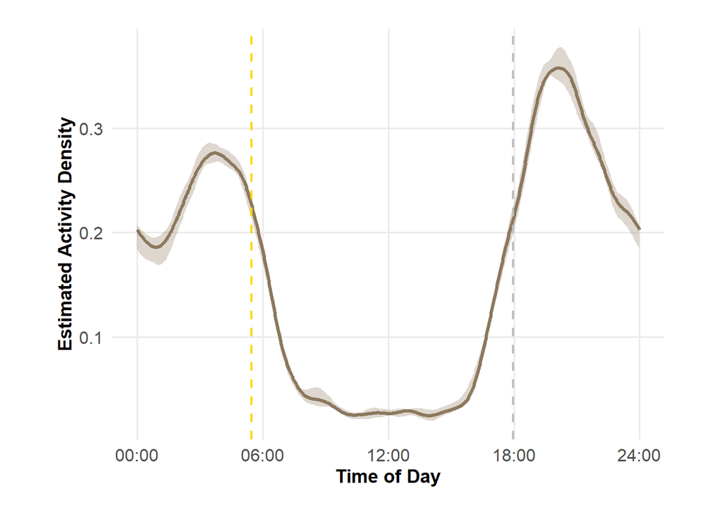

**Figure.26**: *Estimated daily activity pattern for Vulpes vulpes, aggregated across all sampling rounds. Dashed lines indicate the average sunrise (yellow) and sunset (gray) times across survey years. The solid line shows the fitted activity model, and the shaded region shows the 95% CI.*

## 3.5 Richness

Species richness refers to the number of unique species recorded at each camera-trap location. It provides a useful indicator of local biodiversity and helps assess how effectively the survey captured variation in the wildlife community across the study area. The figure below shows the spatial distribution of species richness, where each point represents a camera-trap location. Circle size reflects the number of unique species detected at that site, and color indicates richness intensity, with warmer colors representing higher richness values. By selecting a point, users can view additional information on species composition, richness count, and habitat type, if available. These features help identify biodiversity hotspots and potential detection gaps across the study area.

### 2018

[interactive chart not shown]

**Figure.27**: *Species richness based on the species focus group in this report, across camera-trap locations for survey year 2018.*

### 2019

[interactive chart not shown]

**Figure.28**: *Species richness based on the species focus group in this report, across camera-trap locations for survey year 2019.*

### 2020

[interactive chart not shown]

**Figure.29**: *Species richness based on the species focus group in this report, across camera-trap locations for survey year 2020.*

### 2021

[interactive chart not shown]

**Figure.30**: *Species richness based on the species focus group in this report, across camera-trap locations for survey year 2021.*

### 2022

[interactive chart not shown]

**Figure.31**: *Species richness based on the species focus group in this report, across camera-trap locations for survey year 2022.*

### 2023

[interactive chart not shown]

**Figure.32**: *Species richness based on the species focus group in this report, across camera-trap locations for survey year 2023.*

### 2024

[interactive chart not shown]

**Figure.33**: *Species richness based on the species focus group in this report, across camera-trap locations for survey year 2024.*

### 2025

[interactive chart not shown]

**Figure.34**: *Species richness based on the species focus group in this report, across camera-trap locations for survey year 2025.*

### Total

[interactive chart not shown]

**Figure.35**: *Species richness based on the species focus group in this report, across camera-trap locations for the cumulative dataset across all years.*

## 3.6 Species Co-occurrence

Species co-occurrence analysis was used to assess pairwise associations among species recorded across camera-trap locations. Relationships were summarized in a correlation matrix, where positive values indicate species pairs that tended to co-occur more frequently across sites and negative values indicate lower co-occurrence. Such patterns can provide insight into shared space use or spatial segregation among species, although they should be interpreted cautiously because co-occurrence alone does not imply direct interaction. (*Gotelli, 2000*).

### 2018

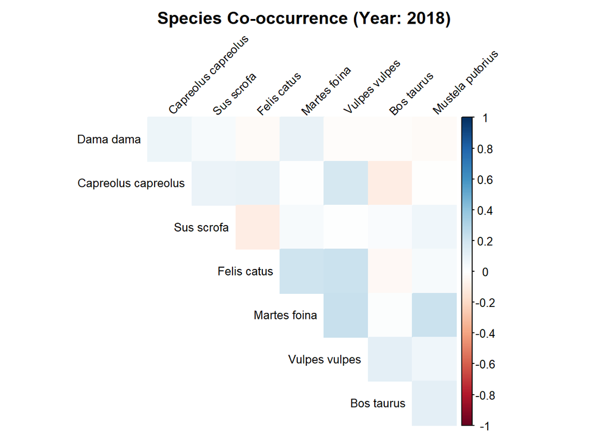

**Figure.36**: *Species co-occurrence patterns for the selected species focus group in this report, shown for survey year 2018.*

### 2019

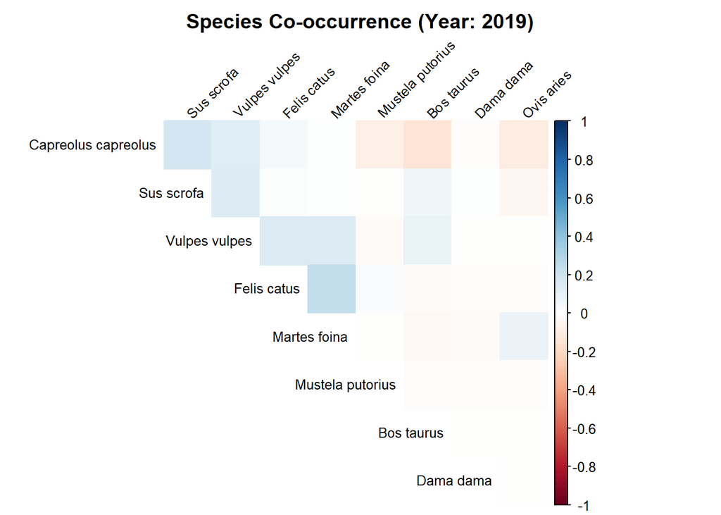

**Figure.37**: *Species co-occurrence patterns for the selected species focus group in this report, shown for survey year 2019.*

### 2020

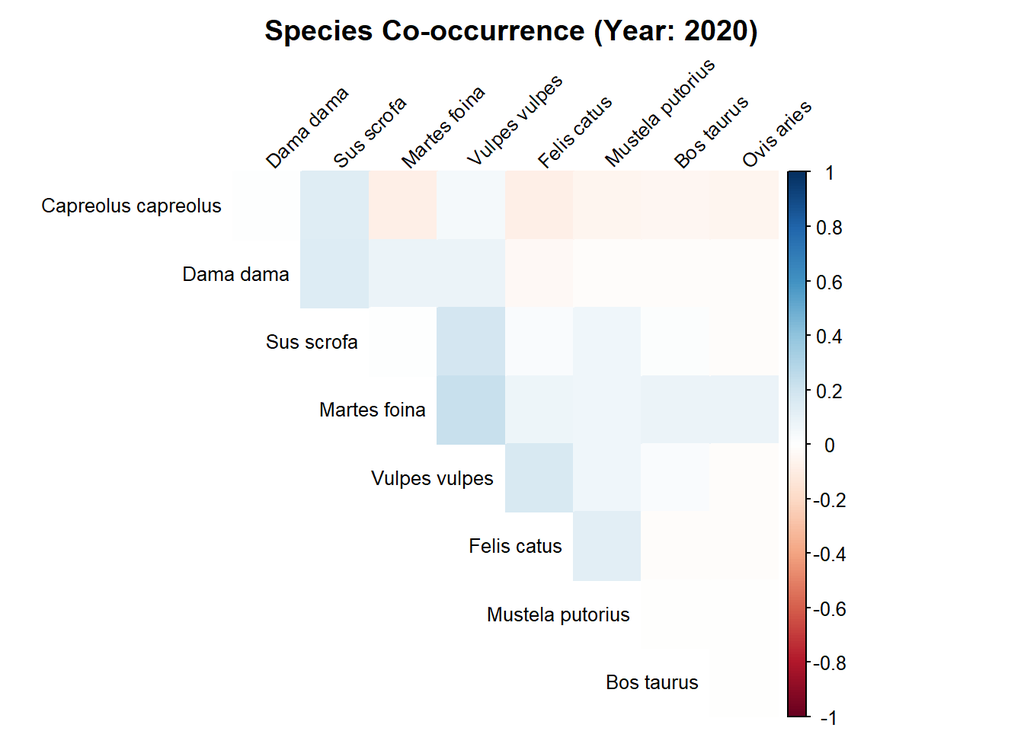

**Figure.38**: *Species co-occurrence patterns for the selected species focus group in this report, shown for survey year 2020.*

### 2021

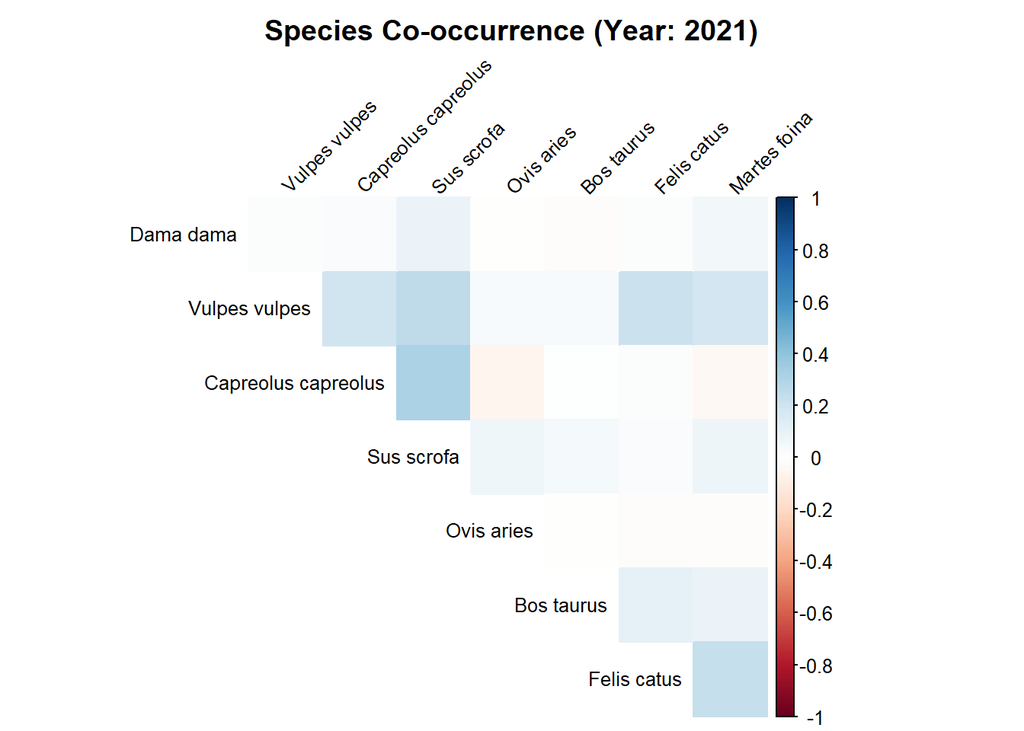

**Figure.39**: *Species co-occurrence patterns for the selected species focus group in this report, shown for survey year 2021.*

### 2022

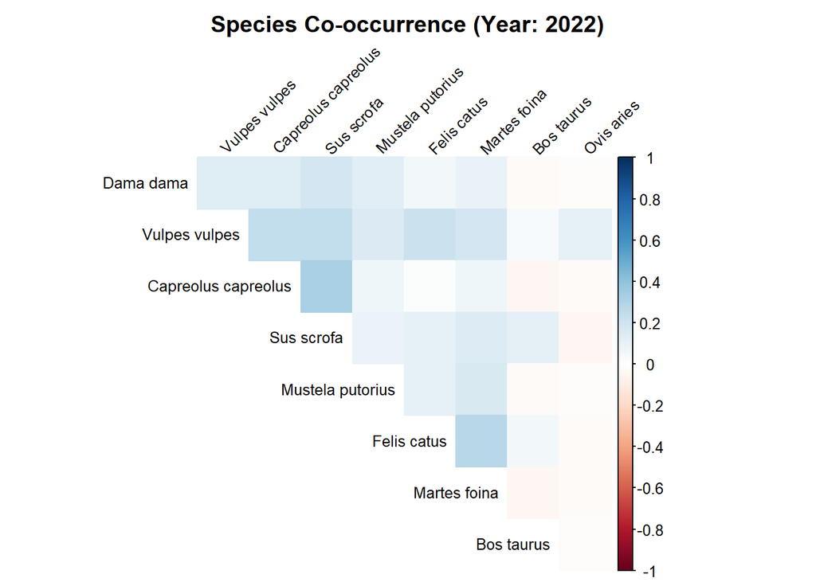

**Figure.40**: *Species co-occurrence patterns for the selected species focus group in this report, shown for survey year 2022.*

### 2023

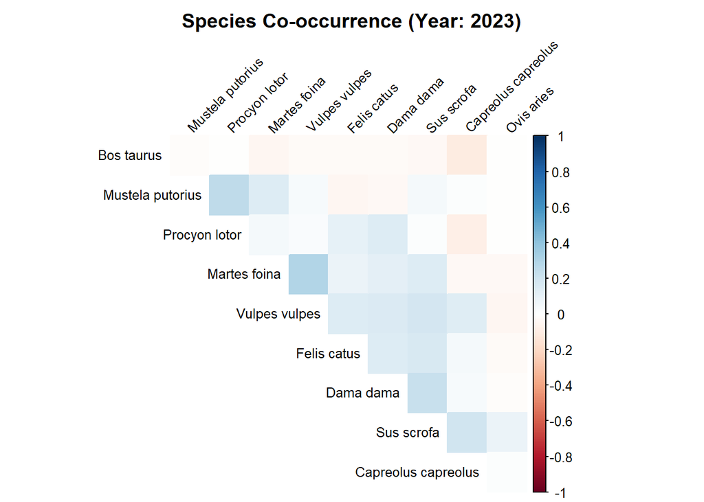

**Figure.41**: *Species co-occurrence patterns for the selected species focus group in this report, shown for survey year 2023.*

### 2024

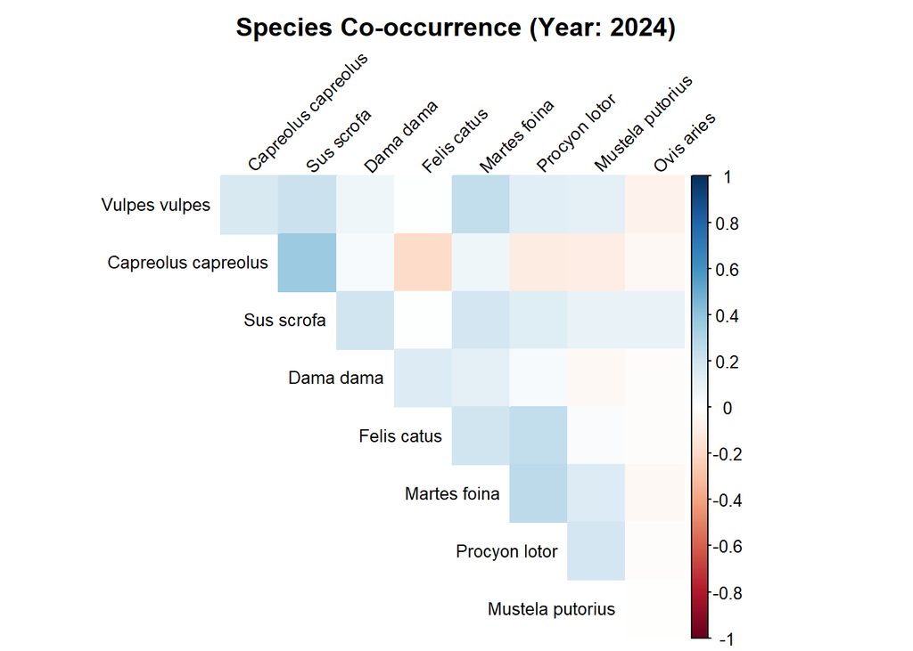

**Figure.42**: *Species co-occurrence patterns for the selected species focus group in this report, shown for survey year 2024.*